# Organize dados de campo com o caderno de campo do jabotR

Este guia apresenta um roteiro completo para `jabot_fieldbook()`, o caderno de campo interativo distribuído com o pacote `jabotR`. Diferentemente das demais funções do `jabotR`, que consultam o serviço web do JABOT, o caderno de campo é uma ferramenta autocontida para organizar novos dados de coleta em campo e transformá-los em uma planilha pronta para submissão ao JABOT.

## Visão Geral da Função

`jabot_fieldbook()` abre o caderno de campo, construído em HTML, CSS e JavaScript puros, no navegador padrão do usuário. Ele funciona totalmente offline, não requer Shiny nem conexão com a internet, e realiza toda a geração da planilha localmente no navegador — nenhum dado sai do computador do usuário. A interface está disponível em português (padrão) e inglês, com um seletor de idioma no canto inferior esquerdo.

[figure not shown]

## Argumentos

| Argumento | Descrição |
| --- | --- |
| `browser` | Lógico. Se `TRUE` (padrão), abre o caderno de campo no navegador padrão. Se `FALSE`, o aplicativo não é aberto e apenas seu caminho local é retornado. |

## Abrindo o Caderno de Campo

```r
jabot_fieldbook()
```

Para obter apenas o caminho local do aplicativo (por exemplo, para abri-lo manualmente ou incorporá-lo em outro lugar) sem abrir uma aba do navegador:

```r
app_path <- jabot_fieldbook(browser = FALSE)
app_path
```

## Como os Dados São Organizados

O caderno de campo é estruturado em torno de **eventos de coleta**. Um evento de coleta representa uma combinação única de data/localidade de coleta — equivalente a uma entrada do caderno de campo em papel — e reúne:

- Um **cabeçalho** compartilhado, preenchido uma única vez e reaproveitado por todos os espécimes coletados naquele evento (data, país, estado, município, localidade, área protegida, habitat, coordenadas, altitude e informações dos coletores).
- Um ou mais **espécimes**, cada um com seus próprios dados taxonômicos e de espécime (número de coleta, família, gênero, espécie, determinador, descrição da planta, entre outros campos).

Um resumo no topo da página mostra, em tempo real, o número de eventos de coleta, o número de espécimes, o percentual de cabeçalhos preenchidos e o número fixo de colunas (58) do formato de planilha Jabot para o qual a ferramenta exporta.

Clique em **Adicionar evento de coleta** para iniciar um novo evento, ou use **Repetir cabeçalho anterior** / **Duplicar cabeçalho** dentro de um evento existente para reaproveitar informações de localidade e data em eventos de coleta próximos, sem precisar redigitá-las.

### Campos do cabeçalho

| Campo | Descrição |
| --- | --- |
| Dia / Mês / Ano | Data da coleta. |
| País, Estado, Município | Divisões político-administrativas onde a coleta ocorreu. |
| Localidade | Localidade dentro do município (fazenda, rio, estrada, comunidade etc.). |
| UC / TI / área protegida | Unidade de conservação, Terra Indígena ou outra área protegida. |
| Habitat | Descrição do habitat do espécime. |
| Latitude / Longitude | Coordenadas em formato decimal. |
| Altitude | Altitude ou profundidade mínima. |
| Coletor / Coletores adicionais | Coletor principal e coletores adicionais. |
| Notas da localidade | Observações livres sobre a localidade de coleta. |

Um painel de **Campos avançados do cabeçalho** expõe colunas adicionais, usadas com menor frequência: coordenadas decompostas em graus/minutos/segundos com hemisfério N/S e E/W, altitude máxima e sua unidade, sigla do herbário de origem, herbários de duplicatas e sua quantidade, e o projeto associado.

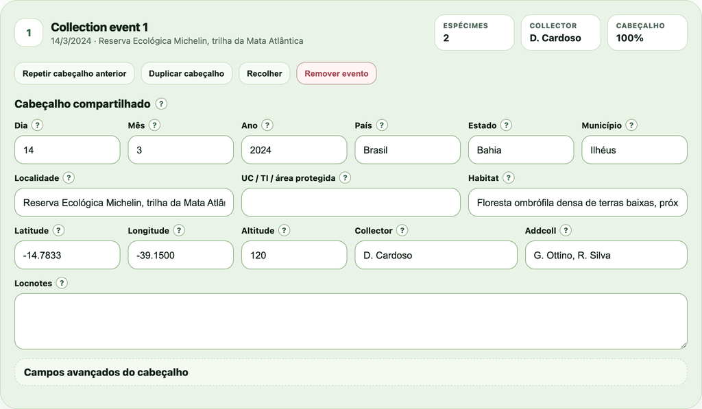

Um evento de coleta com seu cabeçalho compartilhado preenchido — data, localidade, coordenadas, habitat e coletores

### Campos dos espécimes

Cada linha da tabela de espécimes cobre os campos necessários para uma primeira passada rápida — número de coleta, família, gênero, qualificador `cf.`, epíteto da espécie, determinador, data de determinação e uma descrição livre da planta. As larguras das colunas podem ser ajustadas diretamente na tabela.

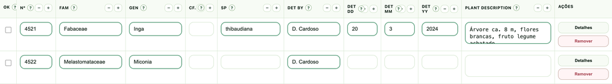

A tabela de espécimes de um evento de coleta, com as ações Detalhes e Remover em cada linha

Ao abrir **Detalhes** de um espécime, é exibida a ficha completa, organizada em quatro grupos:

| Grupo | Campos |
| --- | --- |
| Identificação taxonômica | Família, gênero, `cf.`, espécies 1–3 com autores e categorias infraespecíficas, nome vernacular |
| Coleta e determinação | Número, determinador, data de determinação |
| Descrição do indivíduo | Descrição da planta |
| Uso e observações complementares | Usos, uso específico |

O formulário do caderno mostra apenas os campos mais úteis em campo. As demais colunas do JABOT (`typestat`, `numtombo`, `sufixo`, `flor`, `fruto`, `fuste`, `altura`, `unidmedaltura`, `habito`) não são exibidas, mas sempre são incluídas — vazias — na planilha Jabot exportada, que mantém o leiaute completo de 58 colunas.

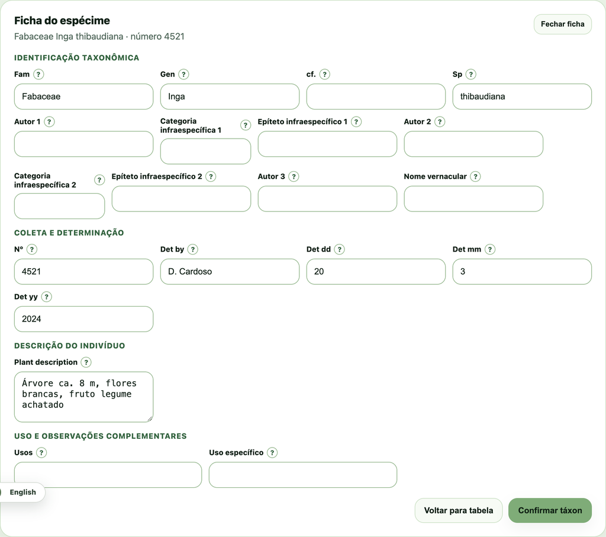

A ficha “Detalhes” do espécime, com seus quatro grupos de campos: identificação taxonômica, coleta e determinação, descrição do indivíduo e uso/observações

Use **Adicionar espécime** para incluir uma nova linha, **Duplicar último** para copiar o espécime anterior como ponto de partida, ou **Seguir sequência numérica** para incrementar automaticamente o número de coleta de um novo espécime.

## Revisão Antes da Exportação

Um painel de validação verifica os dados à medida que são preenchidos e sinaliza, por evento de coleta, problemas como data de coleta incompleta, coletor não informado, evento sem nenhum espécime, ou espécime sem número de coleta ou sem qualquer informação taxonômica (ao menos família, gênero ou espécie). Revise os itens sinalizados antes de exportar; ainda assim é possível gerar a planilha com avisos pendentes, se necessário.

## Salvando e Carregando Rascunhos

- **Salvar rascunho** grava o estado atual do caderno no armazenamento local do navegador, para que o trabalho em andamento não se perca caso a aba seja fechada.
- **Carregar rascunho** restaura o rascunho salvo mais recentemente.

Os rascunhos ficam armazenados apenas no navegador utilizado e não são sincronizados entre dispositivos ou navegadores — salve o rascunho novamente após alterações importantes e evite limpar os dados de navegação do site antes de exportar.

## Exportação

Três opções de exportação estão disponíveis, no topo e ao final da página:

- **Baixar planilha vazia**: gera uma planilha em branco com as 58 colunas do padrão Jabot e nenhum dado, útil como modelo ou para preenchimento direto em um aplicativo de planilha.
- **Gerar planilha Jabot**: exporta todos os eventos de coleta e espécimes preenchidos em uma única planilha no leiaute de colunas padrão do Jabot, pronta para submissão.
- **Gerar caderno de campo (PDF)**: renderiza um caderno de campo imprimível a partir dos dados preenchidos, útil como registro físico ou de arquivo da expedição de coleta.

### O caderno de campo imprimível

O PDF começa com o nome do coletor principal em destaque, com o intervalo de números de coleta logo abaixo. Em seguida vem cada data de coleta em verde, uma linha com a localidade no formato `PAÍS: Estado, Município, Localidade, área protegida, notas da localidade, habitat, coordenadas` e os coletores adicionais, se houver. O coletor não é repetido a cada evento (somente se for diferente do coletor principal). Cada espécime ocupa uma linha: número de coleta, família, nome científico (em itálico) e a descrição da planta, seguidos de qualquer outra informação preenchida para o espécime, como nome vernacular, usos e uso específico.

[figure not shown]

Caderno de campo imprimível (PDF): coletor principal como título, intervalo de números de coleta, eventos de coleta com data e localidade, e uma linha por espécime

## Veja Também

- `jabot_records()`: Recuperar e filtrar registros de espécimes já existentes no JABOT
- `jabot_summary()`: Obter um resumo das coleções do JABOT